# Pertemuan 4_MPDW_Latihan

Zafira Ilma Fitri

2023-09-21

## White Noise

Pembangkitan data berpola AR, MA, ARMA, dan banyak proses deret waktu lainnya diawali pembangkitan *white noise*. *White noise* merupakan sederet nilai dari peubah bebas stokastik identik. Oleh karena itu, *white noise* memiliki dua karakteristik penting:

1. *White noise* tidak memiliki autokorelasi (**karena saling bebas**)
2. Nilai harapan dan ragam *white noise* sama (**karena berasal dari peubah acak bebas stokastik identik**)

*White noise* dibangkitkan dari suatu peubah acak, umumnya peubah acak normal.

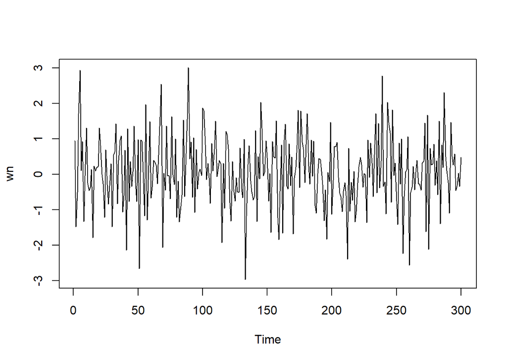

```r
wn <- rnorm(300)
ts.plot(wn)
```

Dapat terlihat bahwa *white noise* tidak memiliki autokorelasi dari ACF. Perhatikan bahwa lag ke-0 adalah korelasi observasi ke-t dengan dirinya sendiri. Nilai korelasi tersebut pasti 1. Sebagai alternatif, lag pertama di plot ACF dapat ditetapkan sebagai 1 (alih-alih 0) dengan menambahkan argumen `xlim(1, lag akhir)`. Plot tersebut dapat disandingkan bersamaan dengan membuat matriks $1 \times 2$ dengan `par(mfrow = c(1,2))`.

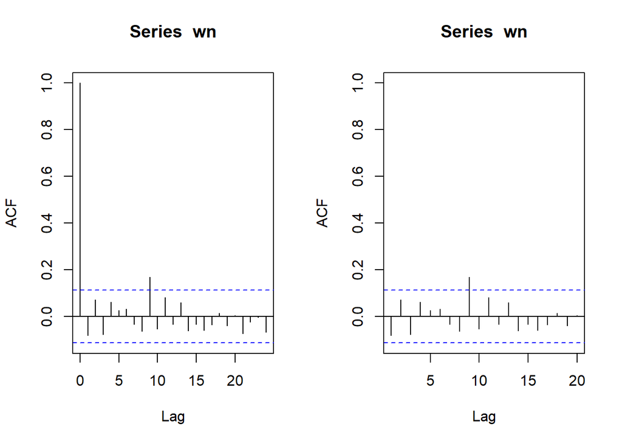

```r
par(mfrow = c(1, 2))
acf(wn)
acf(wn, xlim = c(1, 20))
```

## Proses MA

Proses MA dapat dituliskan sebagai berikut:

$$y_{t} = c + e_t + \theta_{1}e_{t-1} + \theta_{2}e_{t-2} + \dots +
\theta_{q}e_{t-q} = c+{e_t+\sum_{i=1}^p \theta_ie_{t-i}}$$
Terlihat bahwa $e_t$, atau *white noise*, berperan penting dalam pembangkitan proses MA.

## Pembangkitan Proses MA(2)

```r
set.seed(054)
ma <- wn[1]
```

```r
for(i in 3:300){
   ma[i] <- wn[i] + 0.4 * wn[i - 1] + 0.6 * wn[i - 2]
}
ma
```

```
##   [1]  0.942791709           NA -0.537910385  0.625457318  3.317661679
##   [6]  2.314802313  2.738821406 -0.889949543 -0.015969375  0.492423554
##  [11]  0.255047429  0.230207928 -0.700300658 -0.281644106 -1.953776559
##  [16] -0.393684732 -0.879428318  0.372821023  0.358269655  1.509589671
##  [21]  1.475064987  1.110609460  0.229715338 -1.317964464  0.045998587
##  [26] -0.742175286 -0.545272927 -0.840269214 -0.338497186 -1.557057685
##  [31]  0.139426351 -0.023314232  2.012845345  0.131183803  0.914483513
##  [36]  0.616608974  1.703748582 -0.055506975 -0.380357895 -0.198716079
##  [41] -2.227420883  0.838206811 -1.530684866  0.827532654 -0.654102565
##  [46]  0.161045108  1.193510804  0.360056340 -0.040161180  0.526991817
##  [51] -2.732339245  0.488754772 -0.278076051  1.021710887 -0.585863041
##  [56]  1.543649048 -1.199760141  0.508171357  0.658498170 -0.169567478
##  [61]  0.262517417 -0.157396390  0.292372821  0.621510051  0.044324077
##  [66]  0.856864010  1.782080498  3.680422330 -0.073543077  0.736829932
##  [71] -1.671870969  1.200192324  0.234052139  0.754721079 -0.729150848
```

[output cut: 45 more lines]

Selain menggunakan cara di atas, pembangkitan proses MA(2) dapat dilakukan dengan fungsi `arima.sim()` sebagai berikut.

```r
ma2 <- arima.sim(list(order=c(0,0,2), ma=c(0.4, 0.6)), n=300)
ma2
```

```
## Time Series:
## Start = 1
## End = 300
## Frequency = 1
##   [1]  0.96345724  1.77151307  1.59578314  0.39947641  0.26946435 -1.79995676
##   [7]  1.29801380  0.79628634  3.04441420  1.61677916  0.96790024  0.67613162
##  [13] -2.17584186 -1.90968456 -1.56863810 -0.98159071 -0.76176922  0.60276342
##  [19] -1.85935312  0.34187543 -1.06818275  1.18691399  0.98043211  1.97439419
##  [25]  0.57441733 -1.18619323 -0.69155139 -1.82618483  0.29310645  0.19716289
##  [31]  1.13635013  1.81319117  0.57094389  1.11106150  1.85381172 -0.51615422
##  [37]  1.18281250 -1.33103455 -1.69224764 -1.56268819 -0.47396874  0.23450240
##  [43]  0.35749705 -1.87952747 -1.10188581 -1.63284047 -0.47691092 -0.44075218
##  [49] -1.17725838 -0.81964534 -1.32346673 -0.38726858  0.88619765  0.72748488
##  [55]  1.36669234  0.50339714  0.71425042 -0.21485188  0.12753898  0.49210167
##  [61] -0.03889717 -1.07719644  0.77671370  0.82528123 -0.58133416  0.12538027
```

[output cut: 39 more lines]

## Karakteristik MA(2)

### Plot Time Series

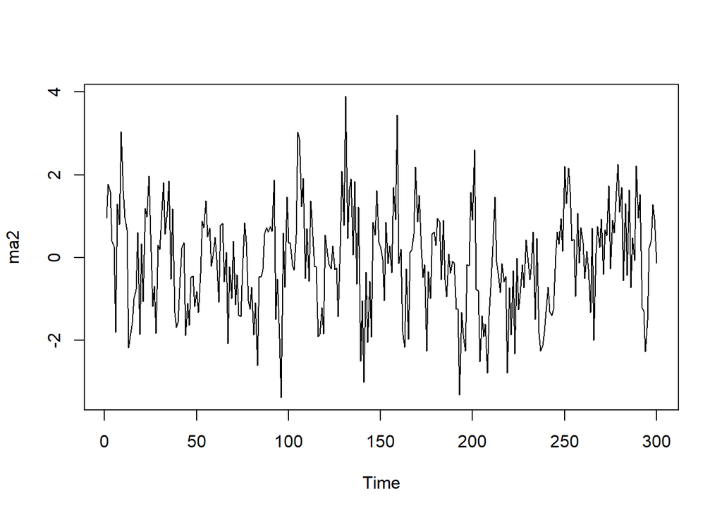

```r
ts.plot(ma2)
```

Berdasarkan plot time series, terlihat bahwa data MA(2) yang dibangkitkan stasioner dalam rataan

### Plot ACF

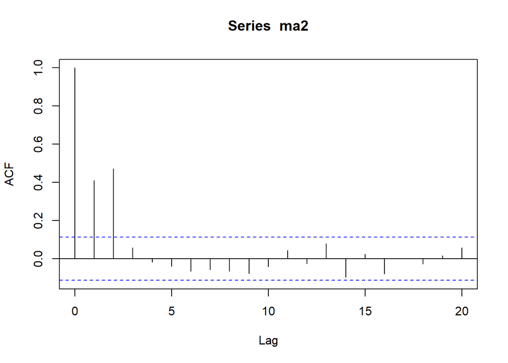

```r
acf(ma2,lag.max = 20)
```

### Plot PACF

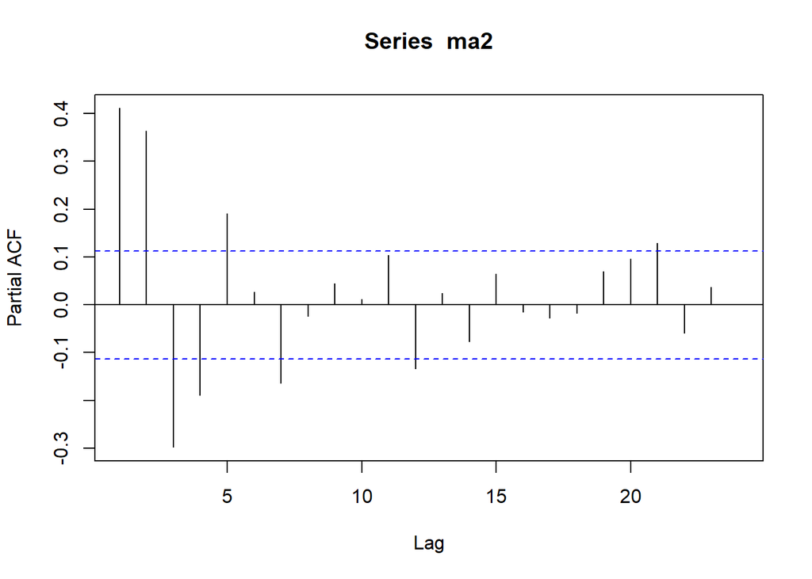

```r
pacf(ma2)
```

Berdasarkan plot PACF tersebut, terlihat bahwa plot PACF cenderung *tails off* dan membentuk gelombang sinus

### Plot EACF

```r
TSA::eacf(ma2)
```

```
## AR/MA
##   0 1 2 3 4 5 6 7 8 9 10 11 12 13
## 0 x x o o o o o o o o o  o  o  o
## 1 x x x o o o o o o o o  o  o  o
## 2 x x x o o o o o o o o  o  o  o
## 3 x x x o x o o o o o o  o  o  x
## 4 x x x x x o o o o o o  o  o  x
## 5 x x x o o o o o o o o  o  o  x
## 6 x x x o o o x o o o o  o  o  o
## 7 x x o x o o o o o o o  o  o  o
```

Berdasarkan pola segitiga nol pada plot EACF, terlihat bahwa segitiga nol berada pada ordo AR(0) dan ordo MA(2)

### Scatterplot Antar Lag

#### Korelasi antara $Y_t$ dengan $Y_{t-1}$

```r
#Yt
yt_ma <- ma2[-1]
yt_ma
```

```
##   [1]  1.77151307  1.59578314  0.39947641  0.26946435 -1.79995676  1.29801380
##   [7]  0.79628634  3.04441420  1.61677916  0.96790024  0.67613162 -2.17584186
##  [13] -1.90968456 -1.56863810 -0.98159071 -0.76176922  0.60276342 -1.85935312
##  [19]  0.34187543 -1.06818275  1.18691399  0.98043211  1.97439419  0.57441733
##  [25] -1.18619323 -0.69155139 -1.82618483  0.29310645  0.19716289  1.13635013
##  [31]  1.81319117  0.57094389  1.11106150  1.85381172 -0.51615422  1.18281250
##  [37] -1.33103455 -1.69224764 -1.56268819 -0.47396874  0.23450240  0.35749705
##  [43] -1.87952747 -1.10188581 -1.63284047 -0.47691092 -0.44075218 -1.17725838
##  [49] -0.81964534 -1.32346673 -0.38726858  0.88619765  0.72748488  1.36669234
##  [55]  0.50339714  0.71425042 -0.21485188  0.12753898  0.49210167 -0.03889717
##  [61] -1.07719644  0.77671370  0.82528123 -0.58133416  0.12538027 -2.07218791
##  [67] -0.22700220 -0.98619586  0.40387703 -1.14085883 -0.41355886 -1.38901510
##  [73] -1.42319079 -0.29102420  0.83585428  0.39101405 -1.03700754 -1.24265962
##  [79] -0.71605912 -1.87529400 -1.08922349 -2.61146514 -0.46283541 -0.45306159
##  [85] -0.29264312  0.56810292  0.72666284  0.62579251  0.75147016  0.62901553
```

[output cut: 35 more lines]

```r
#Yt-1
yt_1_ma <- ma2[-300]
yt_1_ma
```

```
##   [1]  0.96345724  1.77151307  1.59578314  0.39947641  0.26946435 -1.79995676
##   [7]  1.29801380  0.79628634  3.04441420  1.61677916  0.96790024  0.67613162
##  [13] -2.17584186 -1.90968456 -1.56863810 -0.98159071 -0.76176922  0.60276342
##  [19] -1.85935312  0.34187543 -1.06818275  1.18691399  0.98043211  1.97439419
##  [25]  0.57441733 -1.18619323 -0.69155139 -1.82618483  0.29310645  0.19716289
##  [31]  1.13635013  1.81319117  0.57094389  1.11106150  1.85381172 -0.51615422
##  [37]  1.18281250 -1.33103455 -1.69224764 -1.56268819 -0.47396874  0.23450240
##  [43]  0.35749705 -1.87952747 -1.10188581 -1.63284047 -0.47691092 -0.44075218
##  [49] -1.17725838 -0.81964534 -1.32346673 -0.38726858  0.88619765  0.72748488
##  [55]  1.36669234  0.50339714  0.71425042 -0.21485188  0.12753898  0.49210167
##  [61] -0.03889717 -1.07719644  0.77671370  0.82528123 -0.58133416  0.12538027
##  [67] -2.07218791 -0.22700220 -0.98619586  0.40387703 -1.14085883 -0.41355886
##  [73] -1.38901510 -1.42319079 -0.29102420  0.83585428  0.39101405 -1.03700754
##  [79] -1.24265962 -0.71605912 -1.87529400 -1.08922349 -2.61146514 -0.46283541
##  [85] -0.45306159 -0.29264312  0.56810292  0.72666284  0.62579251  0.75147016
```

[output cut: 35 more lines]

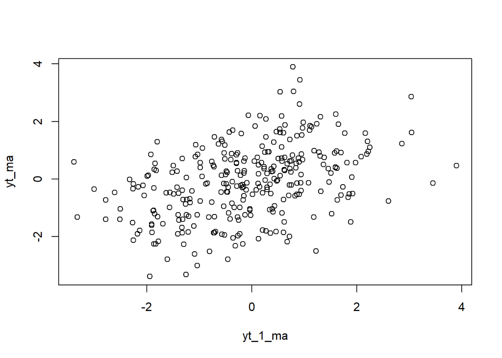

```r
plot(y=yt_ma,x=yt_1_ma)
```

Berdasarkan scatterplot tersebut, terlihat bahwa terdapat hubungan positif antara $Y_t$ dengan $Y_{t-1}$. Hal ini sesuai dengan teori yang ada

```r
cor(yt_ma,yt_1_ma)
```

```
## [1] 0.4115863
```

#### Korelasi antara $Y_t$ dengan $Y_{t-2}$

```r
#Yt
yt_ma2 <- ma2[-c(1,2)]
yt_ma2
```

```
##   [1]  1.59578314  0.39947641  0.26946435 -1.79995676  1.29801380  0.79628634
##   [7]  3.04441420  1.61677916  0.96790024  0.67613162 -2.17584186 -1.90968456
##  [13] -1.56863810 -0.98159071 -0.76176922  0.60276342 -1.85935312  0.34187543
##  [19] -1.06818275  1.18691399  0.98043211  1.97439419  0.57441733 -1.18619323
##  [25] -0.69155139 -1.82618483  0.29310645  0.19716289  1.13635013  1.81319117
##  [31]  0.57094389  1.11106150  1.85381172 -0.51615422  1.18281250 -1.33103455
##  [37] -1.69224764 -1.56268819 -0.47396874  0.23450240  0.35749705 -1.87952747
##  [43] -1.10188581 -1.63284047 -0.47691092 -0.44075218 -1.17725838 -0.81964534
##  [49] -1.32346673 -0.38726858  0.88619765  0.72748488  1.36669234  0.50339714
##  [55]  0.71425042 -0.21485188  0.12753898  0.49210167 -0.03889717 -1.07719644
##  [61]  0.77671370  0.82528123 -0.58133416  0.12538027 -2.07218791 -0.22700220
##  [67] -0.98619586  0.40387703 -1.14085883 -0.41355886 -1.38901510 -1.42319079
##  [73] -0.29102420  0.83585428  0.39101405 -1.03700754 -1.24265962 -0.71605912
##  [79] -1.87529400 -1.08922349 -2.61146514 -0.46283541 -0.45306159 -0.29264312
##  [85]  0.56810292  0.72666284  0.62579251  0.75147016  0.62901553  1.88357671
```

[output cut: 35 more lines]

```r
#Yt-2
yt_2_ma <- ma2[-c(299,300)]
yt_2_ma
```

```
##   [1]  0.96345724  1.77151307  1.59578314  0.39947641  0.26946435 -1.79995676
##   [7]  1.29801380  0.79628634  3.04441420  1.61677916  0.96790024  0.67613162
##  [13] -2.17584186 -1.90968456 -1.56863810 -0.98159071 -0.76176922  0.60276342
##  [19] -1.85935312  0.34187543 -1.06818275  1.18691399  0.98043211  1.97439419
##  [25]  0.57441733 -1.18619323 -0.69155139 -1.82618483  0.29310645  0.19716289
##  [31]  1.13635013  1.81319117  0.57094389  1.11106150  1.85381172 -0.51615422
##  [37]  1.18281250 -1.33103455 -1.69224764 -1.56268819 -0.47396874  0.23450240
##  [43]  0.35749705 -1.87952747 -1.10188581 -1.63284047 -0.47691092 -0.44075218
##  [49] -1.17725838 -0.81964534 -1.32346673 -0.38726858  0.88619765  0.72748488
##  [55]  1.36669234  0.50339714  0.71425042 -0.21485188  0.12753898  0.49210167
##  [61] -0.03889717 -1.07719644  0.77671370  0.82528123 -0.58133416  0.12538027
##  [67] -2.07218791 -0.22700220 -0.98619586  0.40387703 -1.14085883 -0.41355886
##  [73] -1.38901510 -1.42319079 -0.29102420  0.83585428  0.39101405 -1.03700754
##  [79] -1.24265962 -0.71605912 -1.87529400 -1.08922349 -2.61146514 -0.46283541
##  [85] -0.45306159 -0.29264312  0.56810292  0.72666284  0.62579251  0.75147016
```

[output cut: 35 more lines]

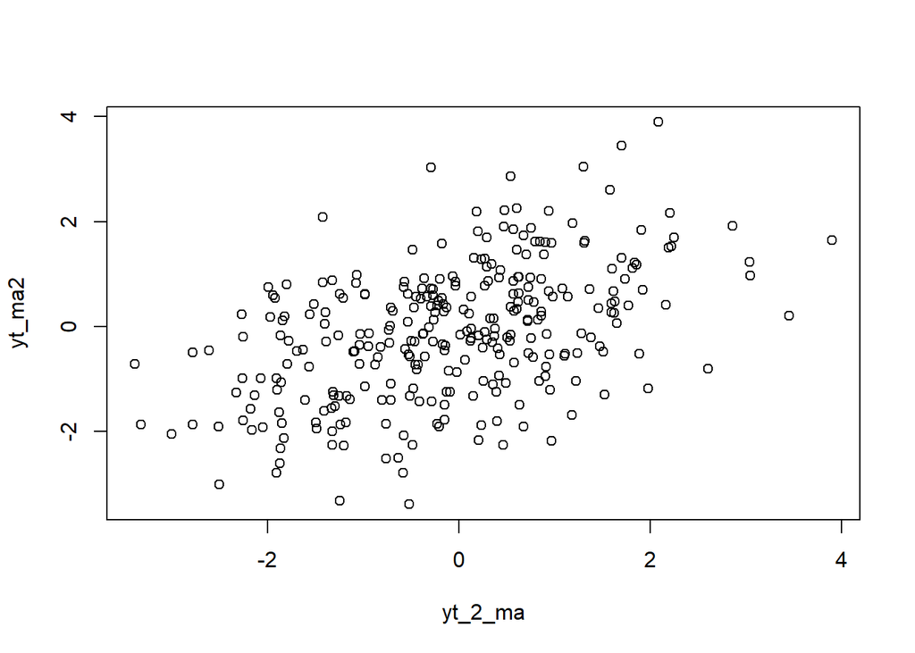

```r
plot(y=yt_ma2,x=yt_2_ma)
```

Berdasarkan scatterplot tersebut, terlihat bahwa cenderung terdapat hubungan positif antara $Y_t$ dengan $Y_{t-2}$.

```r
cor(yt_ma2,yt_2_ma)
```

```
## [1] 0.4738175
```

```r
#Yt
yt_ma3 <- ma2[-c(1,2,3)]
yt_ma3
```

```
##   [1]  0.39947641  0.26946435 -1.79995676  1.29801380  0.79628634  3.04441420
##   [7]  1.61677916  0.96790024  0.67613162 -2.17584186 -1.90968456 -1.56863810
##  [13] -0.98159071 -0.76176922  0.60276342 -1.85935312  0.34187543 -1.06818275
##  [19]  1.18691399  0.98043211  1.97439419  0.57441733 -1.18619323 -0.69155139
##  [25] -1.82618483  0.29310645  0.19716289  1.13635013  1.81319117  0.57094389
##  [31]  1.11106150  1.85381172 -0.51615422  1.18281250 -1.33103455 -1.69224764
##  [37] -1.56268819 -0.47396874  0.23450240  0.35749705 -1.87952747 -1.10188581
##  [43] -1.63284047 -0.47691092 -0.44075218 -1.17725838 -0.81964534 -1.32346673
##  [49] -0.38726858  0.88619765  0.72748488  1.36669234  0.50339714  0.71425042
##  [55] -0.21485188  0.12753898  0.49210167 -0.03889717 -1.07719644  0.77671370
##  [61]  0.82528123 -0.58133416  0.12538027 -2.07218791 -0.22700220 -0.98619586
##  [67]  0.40387703 -1.14085883 -0.41355886 -1.38901510 -1.42319079 -0.29102420
##  [73]  0.83585428  0.39101405 -1.03700754 -1.24265962 -0.71605912 -1.87529400
##  [79] -1.08922349 -2.61146514 -0.46283541 -0.45306159 -0.29264312  0.56810292
##  [85]  0.72666284  0.62579251  0.75147016  0.62901553  1.88357671 -1.49092036
```

[output cut: 35 more lines]

```r
#Yt-3
yt_3_ma <- ma2[-c(298,299,300)]
yt_3_ma
```

```
##   [1]  0.96345724  1.77151307  1.59578314  0.39947641  0.26946435 -1.79995676
##   [7]  1.29801380  0.79628634  3.04441420  1.61677916  0.96790024  0.67613162
##  [13] -2.17584186 -1.90968456 -1.56863810 -0.98159071 -0.76176922  0.60276342
##  [19] -1.85935312  0.34187543 -1.06818275  1.18691399  0.98043211  1.97439419
##  [25]  0.57441733 -1.18619323 -0.69155139 -1.82618483  0.29310645  0.19716289
##  [31]  1.13635013  1.81319117  0.57094389  1.11106150  1.85381172 -0.51615422
##  [37]  1.18281250 -1.33103455 -1.69224764 -1.56268819 -0.47396874  0.23450240
##  [43]  0.35749705 -1.87952747 -1.10188581 -1.63284047 -0.47691092 -0.44075218
##  [49] -1.17725838 -0.81964534 -1.32346673 -0.38726858  0.88619765  0.72748488
##  [55]  1.36669234  0.50339714  0.71425042 -0.21485188  0.12753898  0.49210167
##  [61] -0.03889717 -1.07719644  0.77671370  0.82528123 -0.58133416  0.12538027
##  [67] -2.07218791 -0.22700220 -0.98619586  0.40387703 -1.14085883 -0.41355886
##  [73] -1.38901510 -1.42319079 -0.29102420  0.83585428  0.39101405 -1.03700754
##  [79] -1.24265962 -0.71605912 -1.87529400 -1.08922349 -2.61146514 -0.46283541
##  [85] -0.45306159 -0.29264312  0.56810292  0.72666284  0.62579251  0.75147016
```

[output cut: 35 more lines]

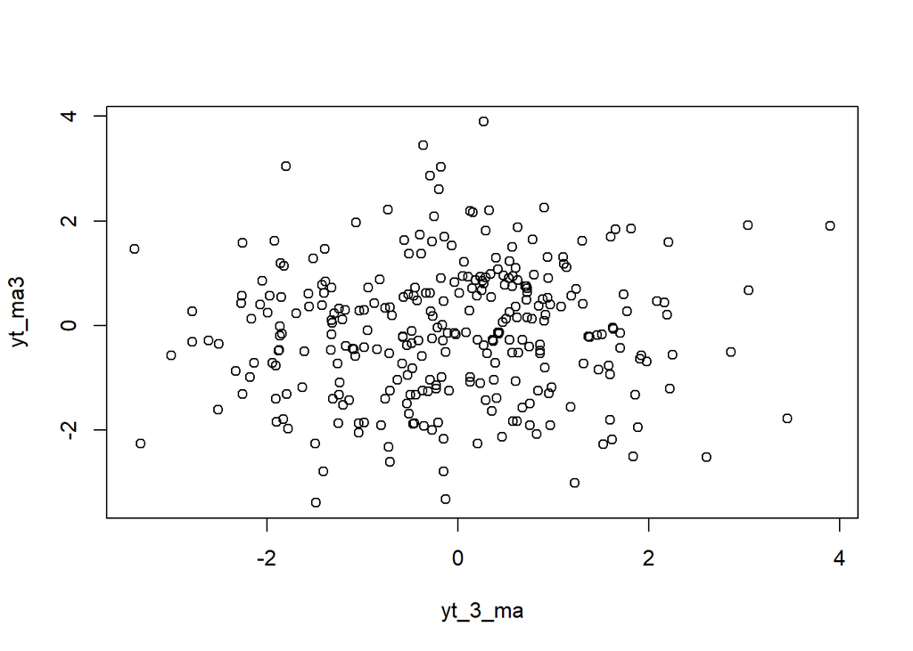

```r
plot(y=yt_ma3,x=yt_3_ma)
```

Berdasarkan scatterplot tersebut, terlihat bahwa cenderung tidak terdapat hubungan antara $Y_t$ dengan $Y_{t-3}$.

```r
cor(yt_ma3,yt_3_ma)
```

```
## [1] 0.05849541
```

Korelasi antara $Y_t$ dengan $Y_{t-3}$ hasil simulasi mendekati teori yang ada yaitu 0.

## Proses AR

Proses AR dapat dituliskan sebagai berikut:

$$y_{t} = c + e_t + \phi_{1}Y_{t-1} +
\phi_{2}Y_{t-2} + \dots + \phi_{q}Y_{t-q} = c+{e_t+\sum_{i=1}^p
\phi_iY_{t-i}}$$
Terlihat bahwa $Y_t$ berperan penting dalam pembangkitan proses AR.

## Pembangkitan Proses AR

Akan dicoba membangkitkan proses AR(2) dengan $\phi = 0.5$ dan $\phi = 0.2$ sebanyak 300 observasi dan $c=0$.

```r
set.seed(054)
```

Nilai-nilai selanjutnya dapat dicari melalui *loop*. Bentuk loop dapat dilihat dari rumus AR(2) yang hendak dibangkitkan:

```r
n<-length(wn)
n
```

```
## [1] 300
```

```r
ar <- c(1:n)
for (i in 3:n) {ar[i]<-wn[i]+0.5*ar[i-1]+0.2*ar[i-2]}
ar
```

```
##   [1]  1.000000000  2.000000000  0.686199906  2.458755282  4.306297226
##   [6]  2.754436943  3.169676651  0.807574313  0.994294431  1.965347695
##  [11]  0.939962750  0.405875466  0.018441794  0.232052549 -1.667231456
##  [16] -0.551105450 -0.510699588 -0.173729494  0.033548777  1.287491950
##  [21]  1.469803268  0.991992393  0.528226718 -0.750515995  0.418635145
##  [26] -0.230443332 -0.873853162 -0.812546428 -0.282313445 -1.782497146
##  [31] -0.395990697  0.088801447  1.389697100 -0.111982899  0.611571470
##  [36]  1.238903773  1.829534816  0.098624963 -0.192230352  0.606227576
##  [41] -1.871330392  0.468615718 -0.902258380  0.005225433 -0.519614020
##  [46] -0.178585679  1.173289699  0.316276170 -0.373407743  0.850815613
##  [51] -2.311596427 -0.016509795  0.461093259  0.294813403 -0.932265645
##  [56]  1.564694066 -0.689477321 -0.192598526  1.259845649 -0.079301302
##  [61] -0.153306561  0.298762738  0.473957390  0.541380593  0.098803712
##  [66]  0.974423599  2.122361628  3.800284855  0.264150496  0.926616261
##  [71]  0.066752198  1.577955663  0.762309504  0.651920684 -0.208787265
```

[output cut: 45 more lines]

Selain menggunakan cara di atas, pembangkitan proses AR dapat dilakukan dengan fungsi `arima.sim()` sebagai berikut.

```r
ar2 <- arima.sim(list(order=c(2,0,0), ar=c(0.5,0.2)), n=300)
ar2
```

```
## Time Series:
## Start = 1
## End = 300
## Frequency = 1
##   [1]  1.571904823  0.667072025 -1.097192721 -0.249115694 -1.189541910
##   [6] -0.112909198  0.197453266  0.696757483  1.657725742  0.658848104
##  [11]  1.133863400  2.548975120 -0.038740022  1.179073343 -0.100705060
##  [16] -1.646977004 -1.263845814 -0.167737044 -0.167438012 -0.303597995
##  [21] -2.091801246 -1.334101225 -1.483350140 -1.189741919 -1.021030962
##  [26] -1.765178292 -1.422060925 -1.643397958 -1.060487659  0.356623928
##  [31]  0.180106274  0.713185115  0.546952973  0.737543950  0.042135014
##  [36]  0.277668038  0.857342532  0.095820053 -1.128512884  1.003808724
##  [41]  1.290657408 -1.070366652  0.006237894 -1.246583931 -0.604768615
##  [46] -0.923429537 -0.040465543 -1.339621624 -0.962903373 -1.343569562
##  [51] -1.878879152 -0.736856082  0.511839661 -0.285633190 -1.673409598
```

[output cut: 49 more lines]

## Karakteristik AR(2)

### Plot Time Series

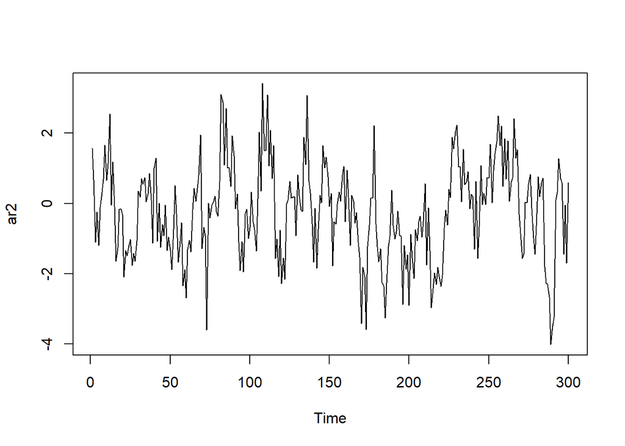

```r
ts.plot(ar2)
```

Berdasarkan plot time series tersebut terlihat bahwa data cenderung stasioner pada rataan

### Plot ACF

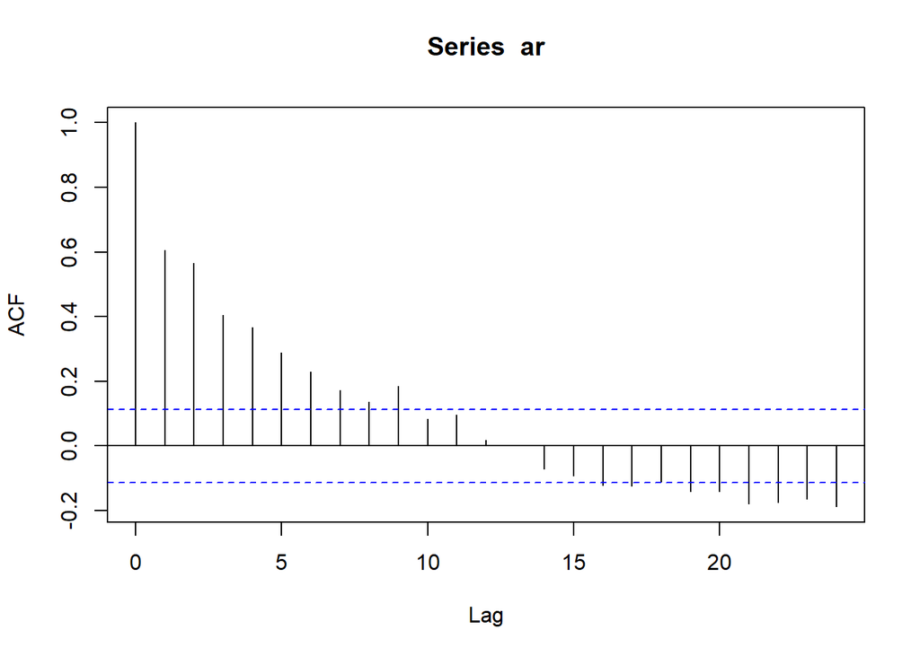

```r
acf(ar)
```

Berdasarkan plot ACF tersebut terlihat bahwa plot ACF cenderung *tails off* dan cenderung membentuk pola grafik sinus

### Plot PACF

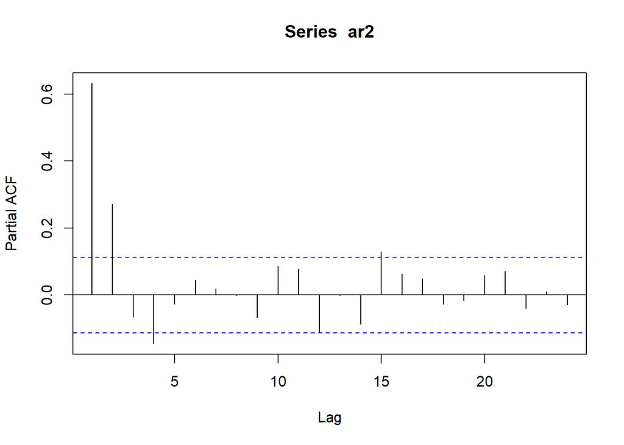

```r
pacf(ar2)
```

### Plot EACF

```r
TSA::eacf(ar2)
```

```
## AR/MA
##   0 1 2 3 4 5 6 7 8 9 10 11 12 13
## 0 x x x x x o o o o o o  o  o  o
## 1 x x o o o o o o o o o  o  o  o
## 2 x x o o o o o o o o o  o  o  o
## 3 x x o o o o o o o o o  o  o  o
## 4 x x o o o o o o o o o  o  o  o
## 5 x x x o o o o o o o o  o  o  o
## 6 x o o o o o o o o o o  o  o  o
## 7 x o x o o o o o o o o  o  o  o
```

Berdasarkan pola segitiga nol pada plot EACF, terlihat bahwa segitiga nol berada pada ordo AR(1) dan ordo MA(2)

### Scatterplot Antar Lag

#### Korelasi antara $Y_t$ dengan $Y_{t-1}$

```r
#Yt
yt_ar <- ar2[-1]
yt_ar
```

```
##   [1]  0.667072025 -1.097192721 -0.249115694 -1.189541910 -0.112909198
##   [6]  0.197453266  0.696757483  1.657725742  0.658848104  1.133863400
##  [11]  2.548975120 -0.038740022  1.179073343 -0.100705060 -1.646977004
##  [16] -1.263845814 -0.167737044 -0.167438012 -0.303597995 -2.091801246
##  [21] -1.334101225 -1.483350140 -1.189741919 -1.021030962 -1.765178292
##  [26] -1.422060925 -1.643397958 -1.060487659  0.356623928  0.180106274
##  [31]  0.713185115  0.546952973  0.737543950  0.042135014  0.277668038
##  [36]  0.857342532  0.095820053 -1.128512884  1.003808724  1.290657408
##  [41] -1.070366652  0.006237894 -1.246583931 -0.604768615 -0.923429537
##  [46] -0.040465543 -1.339621624 -0.962903373 -1.343569562 -1.878879152
##  [51] -0.736856082  0.511839661 -0.285633190 -1.673409598 -1.246797601
##  [56] -0.553176818 -2.351423791 -1.888322746 -2.689835556 -1.314076679
##  [61] -1.046235644 -1.383187586 -0.183098110  0.429731800  0.054225755
##  [66]  0.435386588  0.803035349  1.948976531 -1.284675787 -0.678877235
##  [71] -0.915707194 -3.599376998  0.011964291 -0.418296148 -0.062409625
```

[output cut: 45 more lines]

```r
#Yt-1
yt_1_ar <- ar2[-300]
yt_1_ar
```

```
##   [1]  1.571904823  0.667072025 -1.097192721 -0.249115694 -1.189541910
##   [6] -0.112909198  0.197453266  0.696757483  1.657725742  0.658848104
##  [11]  1.133863400  2.548975120 -0.038740022  1.179073343 -0.100705060
##  [16] -1.646977004 -1.263845814 -0.167737044 -0.167438012 -0.303597995
##  [21] -2.091801246 -1.334101225 -1.483350140 -1.189741919 -1.021030962
##  [26] -1.765178292 -1.422060925 -1.643397958 -1.060487659  0.356623928
##  [31]  0.180106274  0.713185115  0.546952973  0.737543950  0.042135014
##  [36]  0.277668038  0.857342532  0.095820053 -1.128512884  1.003808724
##  [41]  1.290657408 -1.070366652  0.006237894 -1.246583931 -0.604768615
##  [46] -0.923429537 -0.040465543 -1.339621624 -0.962903373 -1.343569562
##  [51] -1.878879152 -0.736856082  0.511839661 -0.285633190 -1.673409598
##  [56] -1.246797601 -0.553176818 -2.351423791 -1.888322746 -2.689835556
##  [61] -1.314076679 -1.046235644 -1.383187586 -0.183098110  0.429731800
##  [66]  0.054225755  0.435386588  0.803035349  1.948976531 -1.284675787
##  [71] -0.678877235 -0.915707194 -3.599376998  0.011964291 -0.418296148
```

[output cut: 45 more lines]

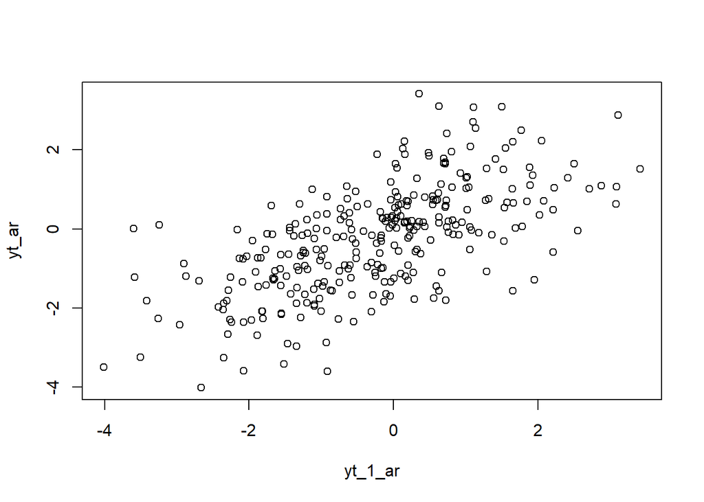

```r
plot(y=yt_ar,x=yt_1_ar)
```

Berdasarkan scatterplot tersebut, terlihat bahwa terdapat hubungan positif antara $Y_t$ dengan $Y_{t-1}$. Hal ini sesuai dengan teori yang ada

```r
cor(yt_ar,yt_1_ar)
```

```
## [1] 0.6345939
```

Korelasi antara $Y_t$ dengan $Y_{t-1}$ dari hasil simulasi sebesar 0.6345939

#### Korelasi antara $Y_t$ dengan $Y_{t-2}$

```r
#Yt
yt_ar2 <- ar2[-c(1,2)]
yt_ar2
```

```
##   [1] -1.097192721 -0.249115694 -1.189541910 -0.112909198  0.197453266
##   [6]  0.696757483  1.657725742  0.658848104  1.133863400  2.548975120
##  [11] -0.038740022  1.179073343 -0.100705060 -1.646977004 -1.263845814
##  [16] -0.167737044 -0.167438012 -0.303597995 -2.091801246 -1.334101225
##  [21] -1.483350140 -1.189741919 -1.021030962 -1.765178292 -1.422060925
##  [26] -1.643397958 -1.060487659  0.356623928  0.180106274  0.713185115
##  [31]  0.546952973  0.737543950  0.042135014  0.277668038  0.857342532
##  [36]  0.095820053 -1.128512884  1.003808724  1.290657408 -1.070366652
##  [41]  0.006237894 -1.246583931 -0.604768615 -0.923429537 -0.040465543
##  [46] -1.339621624 -0.962903373 -1.343569562 -1.878879152 -0.736856082
##  [51]  0.511839661 -0.285633190 -1.673409598 -1.246797601 -0.553176818
##  [56] -2.351423791 -1.888322746 -2.689835556 -1.314076679 -1.046235644
##  [61] -1.383187586 -0.183098110  0.429731800  0.054225755  0.435386588
##  [66]  0.803035349  1.948976531 -1.284675787 -0.678877235 -0.915707194
##  [71] -3.599376998  0.011964291 -0.418296148 -0.062409625  0.017319810
```

[output cut: 45 more lines]

```r
#Yt-2
yt_2_ar <- ar2[-c(299,300)]
yt_2_ar
```

```
##   [1]  1.571904823  0.667072025 -1.097192721 -0.249115694 -1.189541910
##   [6] -0.112909198  0.197453266  0.696757483  1.657725742  0.658848104
##  [11]  1.133863400  2.548975120 -0.038740022  1.179073343 -0.100705060
##  [16] -1.646977004 -1.263845814 -0.167737044 -0.167438012 -0.303597995
##  [21] -2.091801246 -1.334101225 -1.483350140 -1.189741919 -1.021030962
##  [26] -1.765178292 -1.422060925 -1.643397958 -1.060487659  0.356623928
##  [31]  0.180106274  0.713185115  0.546952973  0.737543950  0.042135014
##  [36]  0.277668038  0.857342532  0.095820053 -1.128512884  1.003808724
##  [41]  1.290657408 -1.070366652  0.006237894 -1.246583931 -0.604768615
##  [46] -0.923429537 -0.040465543 -1.339621624 -0.962903373 -1.343569562
##  [51] -1.878879152 -0.736856082  0.511839661 -0.285633190 -1.673409598
##  [56] -1.246797601 -0.553176818 -2.351423791 -1.888322746 -2.689835556
##  [61] -1.314076679 -1.046235644 -1.383187586 -0.183098110  0.429731800
##  [66]  0.054225755  0.435386588  0.803035349  1.948976531 -1.284675787
##  [71] -0.678877235 -0.915707194 -3.599376998  0.011964291 -0.418296148
```

[output cut: 45 more lines]

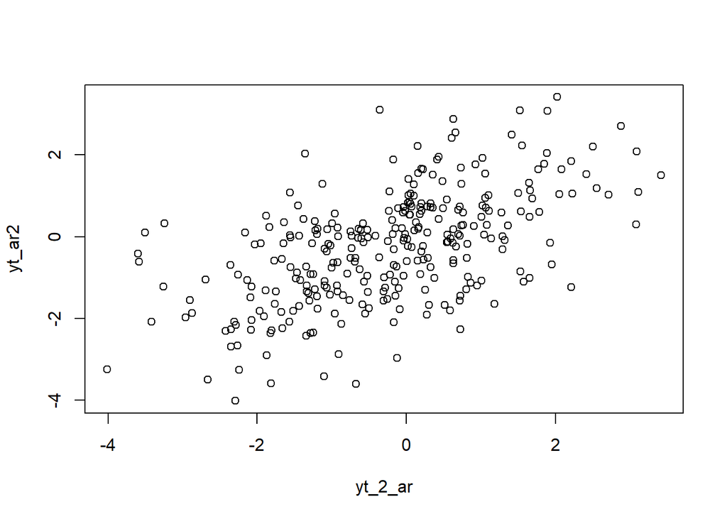

```r
plot(y=yt_ar2,x=yt_2_ar)
```

Berdasarkan scatterplot tersebut, terlihat bahwa terdapat hubungan positif antara $Y_t$ dengan $Y_{t-2}$. Hal ini sesuai dengan teori yang ada

```r
cor(yt_ar2,yt_2_ar)
```

```
## [1] 0.5664674
```

Korelasi antara $Y_t$ dengan $Y_{t-2}$ dari hasil simulasi sebesar 0.5664674

## Fungsi pembangkitan ARMA

Setelah mengetahui cara membangkitkan data berpola AR, MA, dan ARMA sederhana, bagaimana cara melakukan pembangkitan data berpola tersebut yang lebih kompleks? Apakah dapat dibuat suatu fungsi yang fleksibel yang memungkinan pembangkitan dengan berapapun jumlah koefisien?

Pertama, lihat kembali bentuk umum data berpola ARMA.

$$y_{t} = c + \sum_{i=1}^p \phi_{i}y_{t-i} + \sum_{j=1}^q e_{t-j}+ e_{t}$$

Komponen $c$ dan $e_{t}$ cukup mudah untuk dibuat dan dicari. Bagaimana untuk komponen AR dan MA? Bayangkan ada koefisien dan data sebagai berikut:

$$\begin{aligned}
\begin{bmatrix}
\phi_1 \ \phi_2 \ \phi_3
\end{bmatrix}&=
\begin{bmatrix}
0.3 \ 0.5 \ 0.2
\end{bmatrix}
\\
\begin{bmatrix}
y_{t-1} \ y_{t-2} \ y_{t-3}
\end{bmatrix}&=
\begin{bmatrix}
1 \ 2 \ 3
\end{bmatrix}
\end{aligned}$$

Maka dari itu,

$$\begin{aligned}
\begin{bmatrix}
\phi_1 \ \phi_2 \ \phi_3
\end{bmatrix}
\begin{bmatrix}
y_{t-1} \\ y_{t-2} \\ y_{t-3}
\end{bmatrix} &= \phi_1 \ y_{t-1}+\phi_2 \ y_{t-2}+\phi_3 \ y_{t-3}
\\
\begin{bmatrix}
0.3 \ 0.5 \ 0.2
\end{bmatrix}
\begin{bmatrix}
1 \\ 2 \\ 3
\end{bmatrix} & = 0.3 \cdot1+0.5 \cdot 2+0.2 \cdot 3\\
&=0.3+1+0.6 = 1.9
\end{aligned}$$

Jika koefisien dan *white noise*/nilai deret waktu sebelumnya dapat diekstrak dalam bentuk vektor, dapat dilakukan perkalian matriks untuk mencari nilai bagian AR dan MA:

```r
set.seed(054)
n = length(wn)
phi1 = 0.5
phi2 = 0.2
theta1 = 0.4
theta2 = 0.6

y.arma = c(1:n)
for (i in 5:n) {y.arma[i] = phi1 * y.arma[i-1] + phi2 * y.arma[i-2] + theta1 * wn[i-1] + theta2 * wn[i-2] + wn[i]
}
```

## Membangkitkan ARMA dengan fungsi

```r
#contoh untuk ARMA
arma22 <- arima.sim(list(order=c(2,0,2), ar = c(0.5,0.2), ma = c(0.4,0.6)), n=300)
arma22
```

```
## Time Series:
## Start = 1
## End = 300
## Frequency = 1
##   [1]  0.111055717 -0.289063294 -1.948505337 -0.738958882 -0.562017614
##   [6]  0.707549543  2.054562420  1.739735008  2.391841490  3.397679467
##  [11]  1.661053809  2.692875302  0.347613860 -0.979865645 -1.983098243
##  [16] -1.661490993 -0.992862747 -0.471232525 -2.313716286 -2.352990457
##  [21] -3.272078953 -2.583548485 -2.386942216 -2.887439184 -2.740753378
##  [26] -3.271331253 -2.571084885 -1.053611044 -0.313537615  0.999201322
##  [31]  0.940290281  1.384235825  0.665324086  0.737048191  0.993690586
##  [36]  0.605357759 -0.575779443  0.609895527  1.015073109  0.048181502
##  [41]  0.352485645 -1.886308789 -1.099659470 -1.913287356 -0.772698538
##  [46] -1.909865572 -1.523031355 -2.532503890 -2.994049004 -2.294549483
##  [51] -0.910230265 -0.523010976 -1.480559079 -2.087541356 -2.055941618
```

[output cut: 49 more lines]

### Plot Time Series

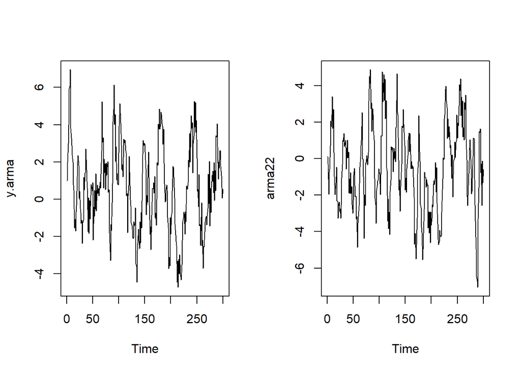

```r
par(mfrow = c(1, 2))
ts.plot(y.arma)
ts.plot(arma22)
```

```r
par(mfrow = c(1, 1))
```

Berdasarkan plot time series tersebut, terlihat bahwa model ARMA(2,2) cenderung stasioner dalam rataan

### Plot ACF

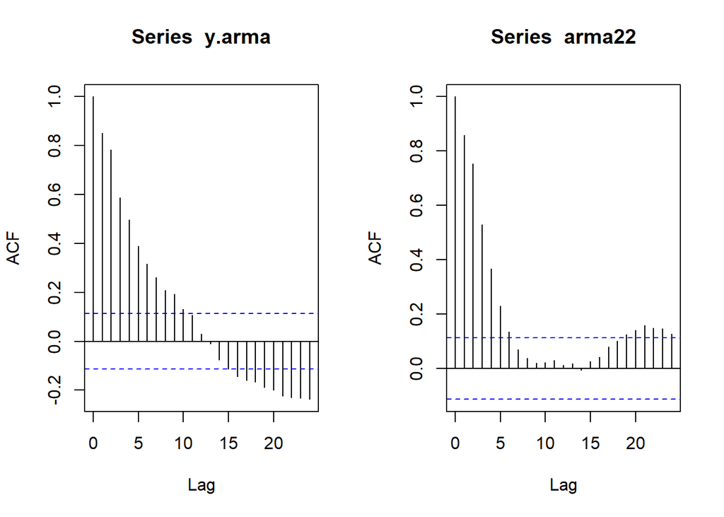

```r
par(mfrow = c(1, 2))
acf(y.arma)
acf(arma22)
```

```r
par(mfrow = c(1, 1))
```

### Plot PACF

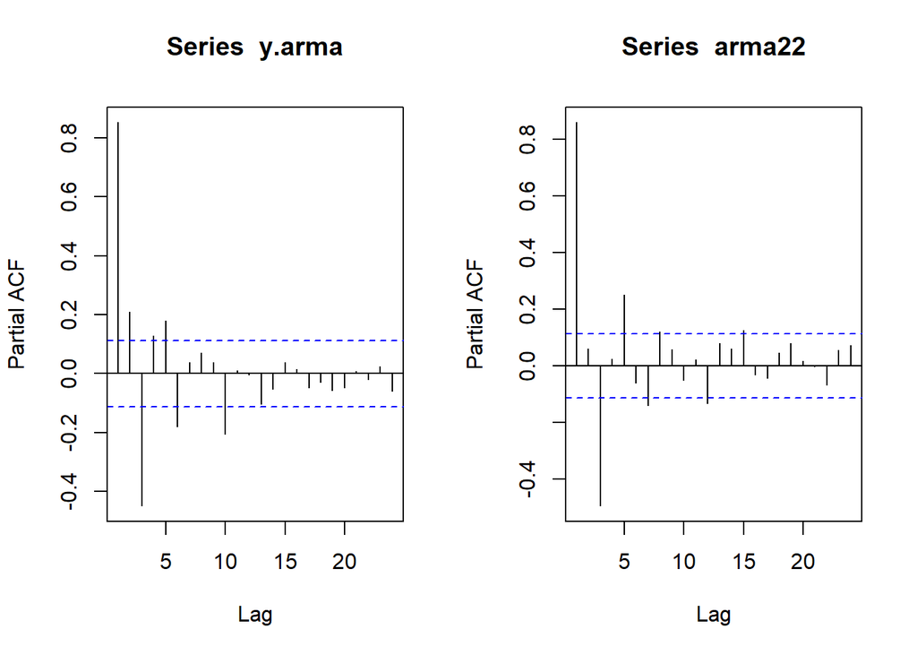

```r
par(mfrow = c(1, 2))
pacf(y.arma)
pacf(arma22)
```

```r
par(mfrow = c(1, 1))
```

Berdasarkan plot PACF tersebut, terlihat bahwa model ARMA(2,2) hasil simulasi memiliki plot PACF yang *tails off*, sesuai dengan teori

### Plot EACF

```r
TSA::eacf(y.arma)
```

```
## AR/MA
##   0 1 2 3 4 5 6 7 8 9 10 11 12 13
## 0 x x x x x x x x x x o  o  o  o
## 1 x x x x o o o x x o o  o  o  o
## 2 x x o o o o o o x o x  o  o  o
## 3 x x o o o o o o x o o  o  o  o
## 4 x x o o o o o o x o o  o  o  o
## 5 x x o x o o o o x o o  o  o  o
## 6 x x o x o o o o x o o  o  o  o
## 7 x x x o o o o x x o o  o  o  o
```

```r
TSA::eacf(arma22)
```

```
## AR/MA
##   0 1 2 3 4 5 6 7 8 9 10 11 12 13
## 0 x x x x x x o o o o o  o  o  o
## 1 o x o o o o o o o o o  o  o  o
## 2 x x o o o o o o o o o  o  o  o
## 3 o x x o o o o o o o o  o  o  o
## 4 x x x o x o o o o o o  o  o  o
## 5 x x o o x o o o o o o  o  o  o
## 6 x x x x o o o o o o o  o  o  o
## 7 x x o x o x o o o o o  o  o  o
```

### Scatterplot Antar Lag

#### Korelasi antara $Y_t$ dengan $Y_{t-1}$

```r
#Yt
yt_arma <- arma22[-1]
yt_arma
```

```
##   [1] -0.289063294 -1.948505337 -0.738958882 -0.562017614  0.707549543
##   [6]  2.054562420  1.739735008  2.391841490  3.397679467  1.661053809
##  [11]  2.692875302  0.347613860 -0.979865645 -1.983098243 -1.661490993
##  [16] -0.992862747 -0.471232525 -2.313716286 -2.352990457 -3.272078953
##  [21] -2.583548485 -2.386942216 -2.887439184 -2.740753378 -3.271331253
##  [26] -2.571084885 -1.053611044 -0.313537615  0.999201322  0.940290281
##  [31]  1.384235825  0.665324086  0.737048191  0.993690586  0.605357759
##  [36] -0.575779443  0.609895527  1.015073109  0.048181502  0.352485645
##  [41] -1.886308789 -1.099659470 -1.913287356 -0.772698538 -1.909865572
##  [46] -1.523031355 -2.532503890 -2.994049004 -2.294549483 -0.910230265
##  [51] -0.523010976 -1.480559079 -2.087541356 -2.055941618 -3.320773080
##  [56] -3.160798353 -4.856018929 -3.523004549 -3.185767649 -2.590127851
##  [61] -1.364114531 -0.473419996  0.116259609  0.714915970  1.009725438
##  [66]  2.531422623 -0.023263965 -0.023361631 -1.958063560 -4.372986216
##  [71] -1.977210824 -2.573136630 -0.222549509 -0.258621729  0.172401037
```

[output cut: 45 more lines]

```r
#Yt-1
yt_1_arma <- arma22[-300]
yt_1_arma
```

```
##   [1]  0.111055717 -0.289063294 -1.948505337 -0.738958882 -0.562017614
##   [6]  0.707549543  2.054562420  1.739735008  2.391841490  3.397679467
##  [11]  1.661053809  2.692875302  0.347613860 -0.979865645 -1.983098243
##  [16] -1.661490993 -0.992862747 -0.471232525 -2.313716286 -2.352990457
##  [21] -3.272078953 -2.583548485 -2.386942216 -2.887439184 -2.740753378
##  [26] -3.271331253 -2.571084885 -1.053611044 -0.313537615  0.999201322
##  [31]  0.940290281  1.384235825  0.665324086  0.737048191  0.993690586
##  [36]  0.605357759 -0.575779443  0.609895527  1.015073109  0.048181502
##  [41]  0.352485645 -1.886308789 -1.099659470 -1.913287356 -0.772698538
##  [46] -1.909865572 -1.523031355 -2.532503890 -2.994049004 -2.294549483
##  [51] -0.910230265 -0.523010976 -1.480559079 -2.087541356 -2.055941618
##  [56] -3.320773080 -3.160798353 -4.856018929 -3.523004549 -3.185767649
##  [61] -2.590127851 -1.364114531 -0.473419996  0.116259609  0.714915970
##  [66]  1.009725438  2.531422623 -0.023263965 -0.023361631 -1.958063560
##  [71] -4.372986216 -1.977210824 -2.573136630 -0.222549509 -0.258621729
```

[output cut: 45 more lines]

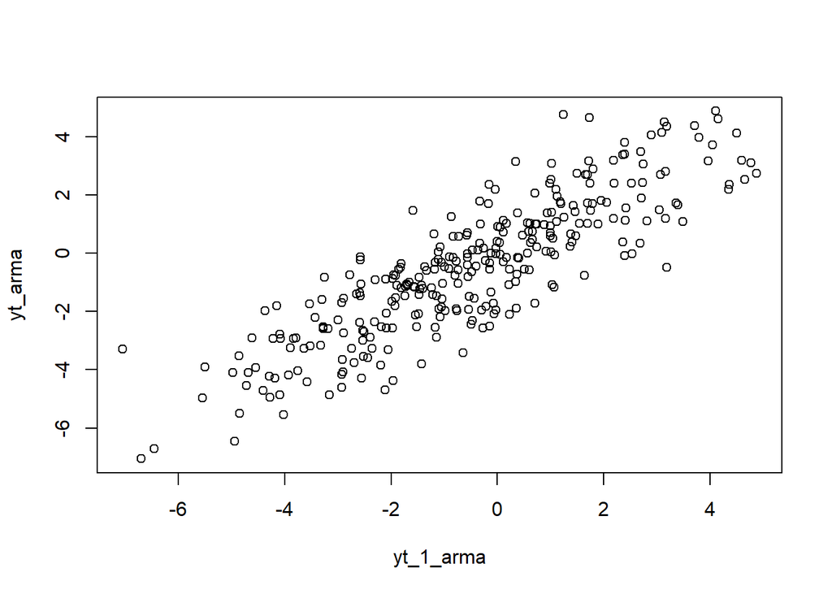

```r
plot(y=yt_arma,x=yt_1_arma)
```

Berdasarkan scatterplot tersebut, terlihat bahwa terdapat hubungan positif antara $Y_t$ dengan $Y_{t-1}$. Hal ini sesuai dengan teori yang ada

```r
cor(yt_arma,yt_1_arma)
```

```
## [1] 0.8586393
```

```r
#Yt
yt_arma2 <- arma22[-c(1,2)]
#Yt-2
yt_2_arma <- arma22[-c(299,300)]
yt_2_arma
```

```
##   [1]  0.111055717 -0.289063294 -1.948505337 -0.738958882 -0.562017614
##   [6]  0.707549543  2.054562420  1.739735008  2.391841490  3.397679467
##  [11]  1.661053809  2.692875302  0.347613860 -0.979865645 -1.983098243
##  [16] -1.661490993 -0.992862747 -0.471232525 -2.313716286 -2.352990457
##  [21] -3.272078953 -2.583548485 -2.386942216 -2.887439184 -2.740753378
##  [26] -3.271331253 -2.571084885 -1.053611044 -0.313537615  0.999201322
##  [31]  0.940290281  1.384235825  0.665324086  0.737048191  0.993690586
##  [36]  0.605357759 -0.575779443  0.609895527  1.015073109  0.048181502
##  [41]  0.352485645 -1.886308789 -1.099659470 -1.913287356 -0.772698538
##  [46] -1.909865572 -1.523031355 -2.532503890 -2.994049004 -2.294549483
##  [51] -0.910230265 -0.523010976 -1.480559079 -2.087541356 -2.055941618
##  [56] -3.320773080 -3.160798353 -4.856018929 -3.523004549 -3.185767649
##  [61] -2.590127851 -1.364114531 -0.473419996  0.116259609  0.714915970
##  [66]  1.009725438  2.531422623 -0.023263965 -0.023361631 -1.958063560
##  [71] -4.372986216 -1.977210824 -2.573136630 -0.222549509 -0.258621729
```

[output cut: 45 more lines]

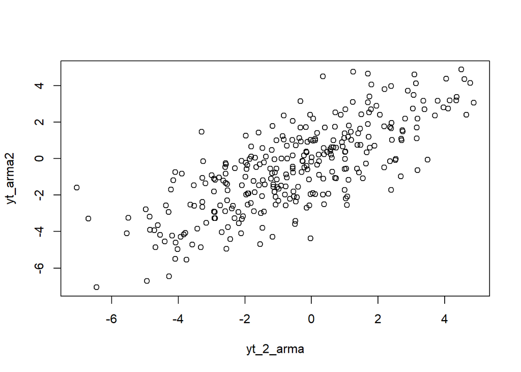

```r
plot(y=yt_arma2,x=yt_2_arma)
```

```r
cor(yt_arma2,yt_2_arma)
```

```
## [1] 0.7527434
```

```r
#Yt
yt_arma3 <- arma22[-c(1,2,3)]
#Yt-2
yt_3_arma <- arma22[-c(298,299,300)]
yt_3_arma
```

```
##   [1]  0.111055717 -0.289063294 -1.948505337 -0.738958882 -0.562017614
##   [6]  0.707549543  2.054562420  1.739735008  2.391841490  3.397679467
##  [11]  1.661053809  2.692875302  0.347613860 -0.979865645 -1.983098243
##  [16] -1.661490993 -0.992862747 -0.471232525 -2.313716286 -2.352990457
##  [21] -3.272078953 -2.583548485 -2.386942216 -2.887439184 -2.740753378
##  [26] -3.271331253 -2.571084885 -1.053611044 -0.313537615  0.999201322
##  [31]  0.940290281  1.384235825  0.665324086  0.737048191  0.993690586
##  [36]  0.605357759 -0.575779443  0.609895527  1.015073109  0.048181502
##  [41]  0.352485645 -1.886308789 -1.099659470 -1.913287356 -0.772698538
##  [46] -1.909865572 -1.523031355 -2.532503890 -2.994049004 -2.294549483
##  [51] -0.910230265 -0.523010976 -1.480559079 -2.087541356 -2.055941618
##  [56] -3.320773080 -3.160798353 -4.856018929 -3.523004549 -3.185767649
##  [61] -2.590127851 -1.364114531 -0.473419996  0.116259609  0.714915970
##  [66]  1.009725438  2.531422623 -0.023263965 -0.023361631 -1.958063560
##  [71] -4.372986216 -1.977210824 -2.573136630 -0.222549509 -0.258621729
```

[output cut: 45 more lines]

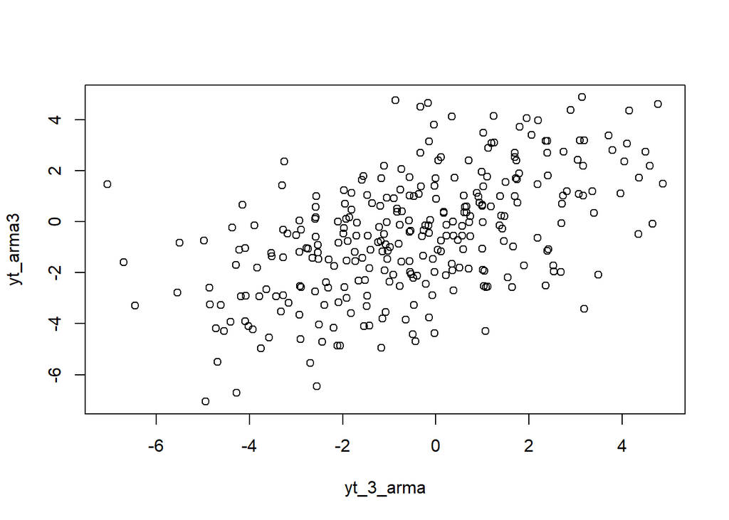

```r
plot(y=yt_arma3,x=yt_3_arma)
```

```r
cor(yt_arma3,yt_3_arma)
```

```
## [1] 0.5291941
```